# Data analysis on prostate cancer

Group 8

Seahwa Lee

07/05/2020

## Introduction

Topic: Prostate cancer data analysis Data source: Vanderbilt biostatistics dataset

## Variables

- Two types:-

| -Categorical | Numerical |
| --- | --- |
| “activity” | “PA_phosphatase” |
| “status_” | “age” |
| “cause_of_death” | “diastolic_bp” |
| “bone_metastases” | “months_of_follow_up” |
| “ekg” | “serum_hemoglobin” |
|  | “history_of_CD” |
|  | “tumor_size” |
|  | “study_date” |
|  | “weight_index” |
|  | “estrogen_mg” |
|  | “dead_from_prostate_cancer” |
|  | “Age_group” |
|  | “stage” |
|  | “systolic_bp” |
|  | “stage_grade_index” |

## Data cleaning

- Importing the file into data table format
- Conversion of character types into numerical values for better analysis e.g. placebo–> ‘0’ mg estrogen
- Writing variables in more ‘readable’ format e.g. sz–> tumor size

## Data analysis

- Error and Trial method- built lots of linear models using different combinations of varibles
- At the end, found out the linear model of the highest R squared value stratified on cause of death.

## ANOVA test

- Analysis of Variance (ANOVA) test is a statistical tool to measure how significant the effect of independent variables are within and between groups.

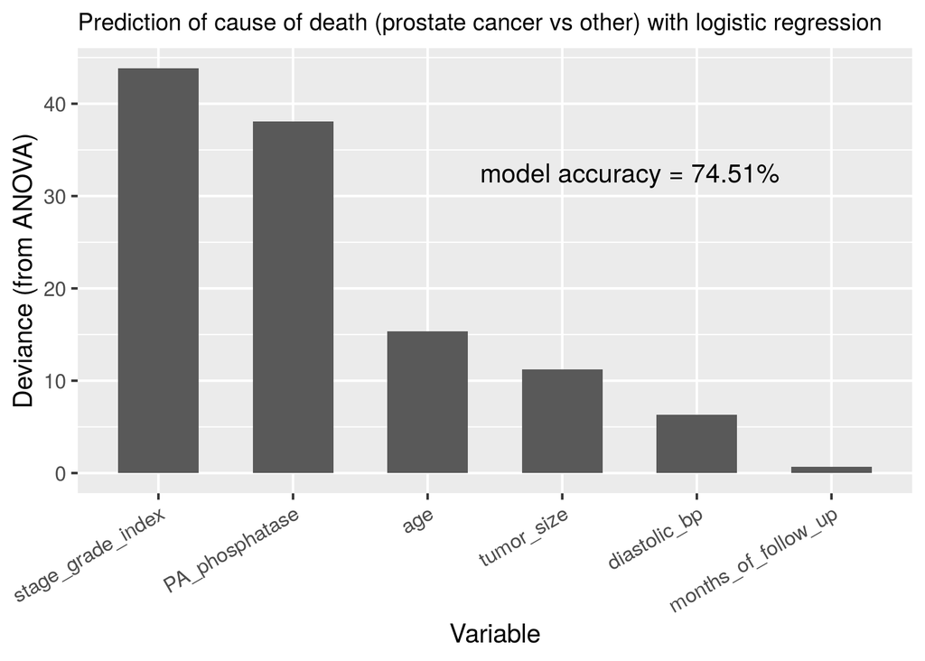